# Estudios de Informática, Multimedia y Telecomunicaciones

### 2.3.3 Correlation plots

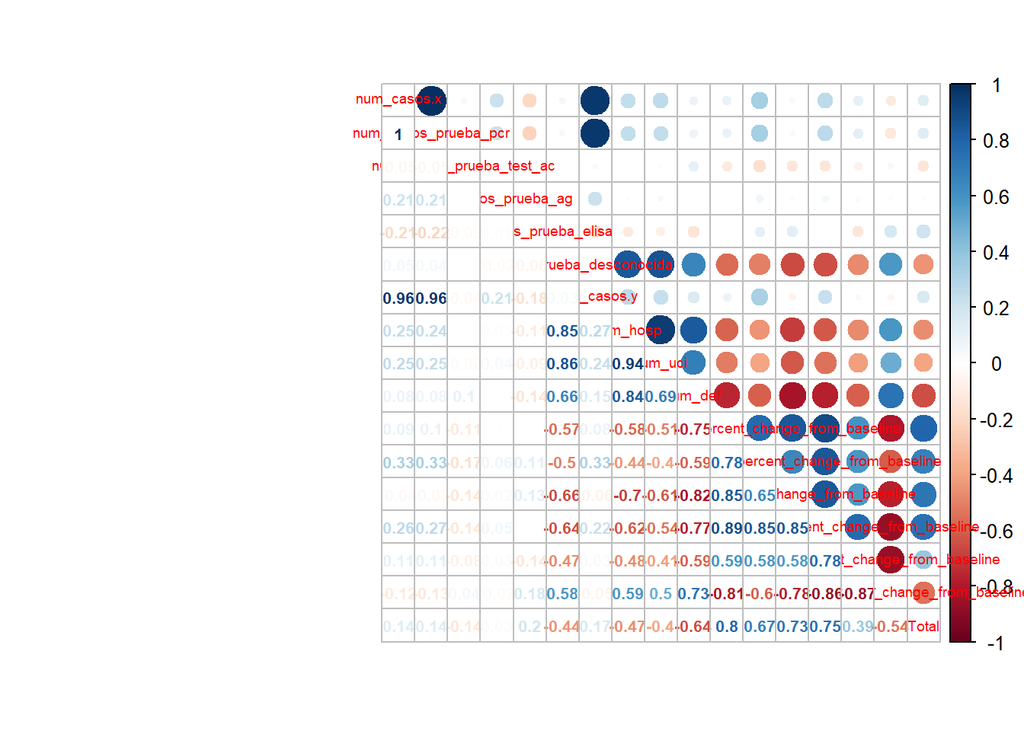

```r
# Filter to "sub_region_2" == "Barcelona"
# Character / date columns are eliminated

# pearson
Total.res<-Total %>%
  filter(sub_region_2 == "Barcelona")
Total.res<-cor(Total.res[,c(-1,-2,-3)],method="pearson")
corrplot.mixed(Total.res,upper="circle",number.cex=.65,tl.cex=.6)
```

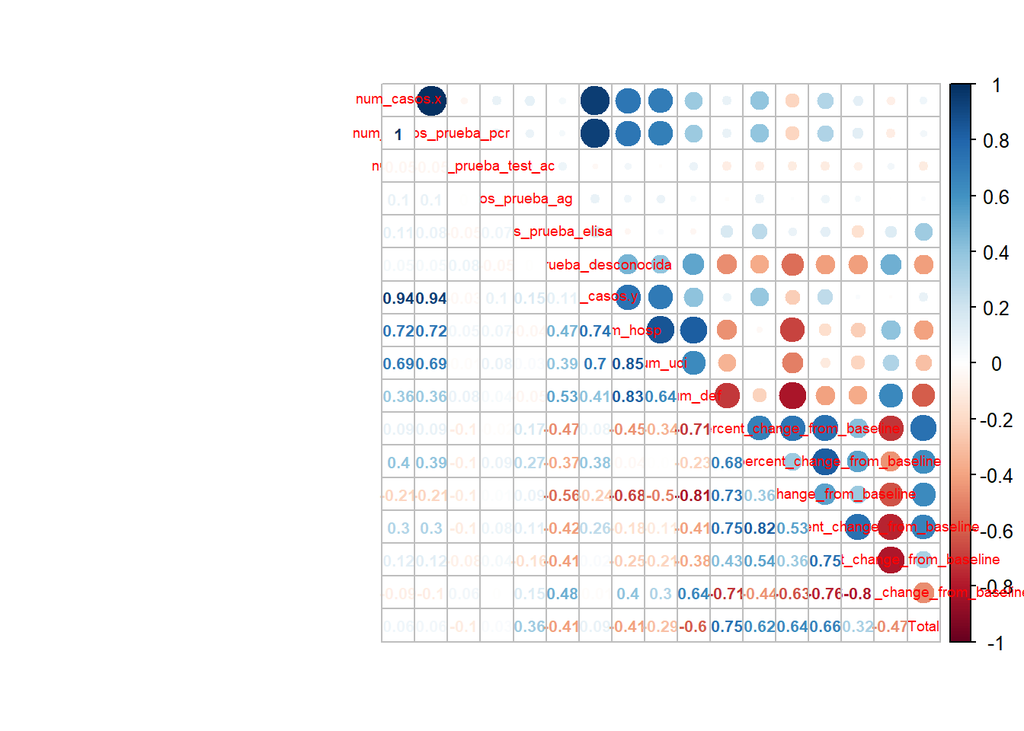

```r
# spearman
Total.res<-Total %>%
  filter(sub_region_2 == "Barcelona")
Total.res<-cor(Total.res[,c(-1,-2,-3)],method="spearman")
corrplot.mixed(Total.res,upper="circle",number.cex=.65,tl.cex=.6)
```

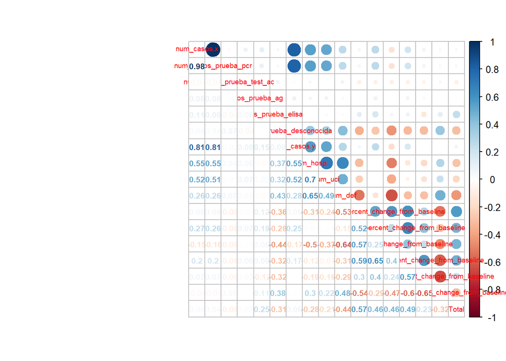

```r
# kendall
Total.res<-Total %>%
  filter(sub_region_2 == "Barcelona")
Total.res<-cor(Total.res[,c(-1,-2,-3)],method="kendall")
corrplot.mixed(Total.res,upper="circle",number.cex=.65,tl.cex=.6)
```

### 2.3.4 PCA

```r
pca <- prcomp(Total.res, scale = T)
summary(pca)
```

```
## Importance of components:
##                           PC1    PC2     PC3     PC4     PC5     PC6     PC7
## Standard deviation     3.0590 1.8914 1.12142 1.02409 0.83504 0.57825 0.46266
## Proportion of Variance 0.5504 0.2104 0.07398 0.06169 0.04102 0.01967 0.01259
## Cumulative Proportion  0.5504 0.7609 0.83485 0.89655 0.93756 0.95723 0.96982
##                            PC8     PC9    PC10    PC11    PC12    PC13    PC14
## Standard deviation     0.41006 0.33620 0.28445 0.21986 0.17734 0.16911 0.15372
## Proportion of Variance 0.00989 0.00665 0.00476 0.00284 0.00185 0.00168 0.00139
## Cumulative Proportion  0.97971 0.98636 0.99112 0.99397 0.99582 0.99750 0.99889
##                          PC15    PC16      PC17
## Standard deviation     0.1369 0.01274 1.826e-17
## Proportion of Variance 0.0011 0.00001 0.000e+00
## Cumulative Proportion  1.0000 1.00000 1.000e+00
```

```r
pca$rotation
```

```
##                                                              PC1          PC2
## num_casos.x                                        -0.1354826901 -0.469400471
## num_casos_prueba_pcr                               -0.1356873829 -0.469237915
## num_casos_prueba_test_ac                           -0.0782958432  0.237502756
## num_casos_prueba_ag                                 0.0005323686  0.008790618
## num_casos_prueba_elisa                              0.0495912937  0.004385553
## num_casos_prueba_desconocida                       -0.2907430443  0.113686282
## num_casos.y                                        -0.1546876637 -0.450080493
## num_hosp                                           -0.2956764064 -0.199498016
## num_uci                                            -0.2788863801 -0.230508957
## num_def                                            -0.3153112111 -0.030904089
## retail_and_recreation_percent_change_from_baseline  0.3077977291 -0.116093786
## grocery_and_pharmacy_percent_change_from_baseline   0.2553316609 -0.261732823
## parks_percent_change_from_baseline                  0.3128404870  0.012776948
## transit_stations_percent_change_from_baseline       0.2855716515 -0.218931952
## workplaces_percent_change_from_baseline             0.2622358364 -0.170838668
## residential_percent_change_from_baseline           -0.2895648649  0.166332144
## Total                                               0.2993175108 -0.081611685
##                                                             PC3          PC4
## num_casos.x                                        -0.002875288 -0.028445983
## num_casos_prueba_pcr                               -0.012292151 -0.026795983
## num_casos_prueba_test_ac                           -0.392712472 -0.268237834
## num_casos_prueba_ag                                -0.034460138  0.950253303
## num_casos_prueba_elisa                              0.811470962 -0.060011278
## num_casos_prueba_desconocida                        0.019674417 -0.078105637
## num_casos.y                                         0.041668217 -0.036946432
## num_hosp                                           -0.051419434 -0.010413059
## num_uci                                            -0.018126448  0.006323566
## num_def                                            -0.031133681  0.009747098
## retail_and_recreation_percent_change_from_baseline  0.033200491 -0.075398568
## grocery_and_pharmacy_percent_change_from_baseline   0.027494995 -0.030995413
## parks_percent_change_from_baseline                  0.029299658 -0.011018427
## transit_stations_percent_change_from_baseline      -0.099387689 -0.018021579
## workplaces_percent_change_from_baseline            -0.303553292  0.028981871
## residential_percent_change_from_baseline            0.211975965  0.003369575
## Total                                               0.173800838 -0.065471155
##                                                            PC5         PC6
## num_casos.x                                        -0.15653475  0.16549669
## num_casos_prueba_pcr                               -0.15256567  0.17028866
## num_casos_prueba_test_ac                           -0.81534671 -0.10365823
```

[output cut: 107 more lines]

```
## num_casos_prueba_test_ac                            0.09544863
## num_casos_prueba_ag                                 0.05828430
## num_casos_prueba_elisa                              0.04498527
## num_casos_prueba_desconocida                        0.16508413
## num_casos.y                                        -0.01242631
## num_hosp                                            0.04584112
## num_uci                                             0.06322805
## num_def                                             0.30912666
## retail_and_recreation_percent_change_from_baseline  0.33484091
## grocery_and_pharmacy_percent_change_from_baseline  -0.13871900
## parks_percent_change_from_baseline                  0.41803506
## transit_stations_percent_change_from_baseline       0.04834211
## workplaces_percent_change_from_baseline             0.44739326
## residential_percent_change_from_baseline            0.57600490
## Total                                               0.07657033
```

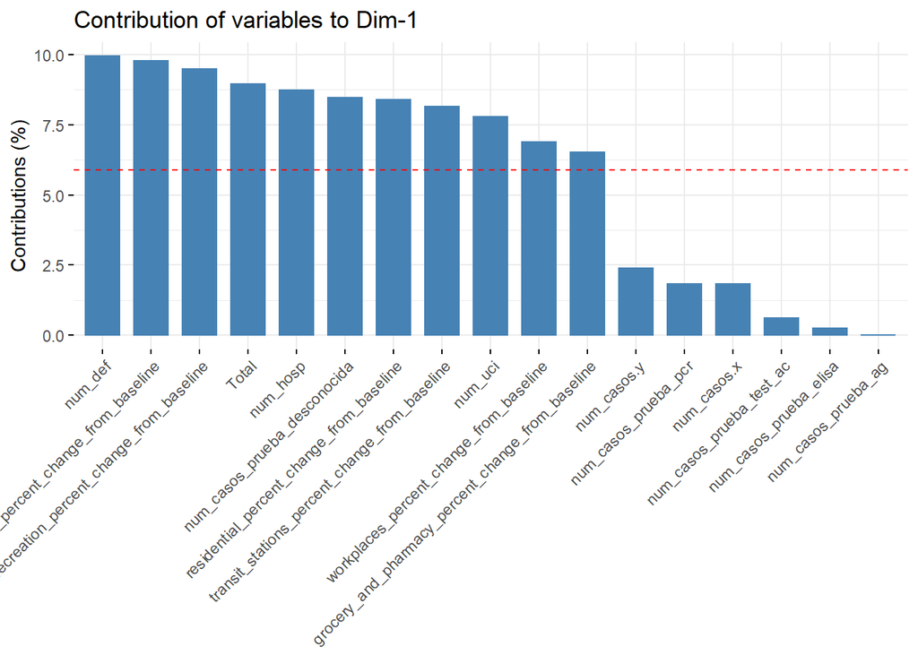

```r
if(!require(FactoMineR)){
    install.packages('FactoMineR', repos='http://cran.us.r-project.org')
    library(FactoMineR)}
if(!require(factoextra)){
    install.packages('factoextra', repos='http://cran.us.r-project.org')
    library(factoextra)}

# Var contribution for PC1-PC5
fviz_contrib(pca, choice = "var", axes = 1)
```

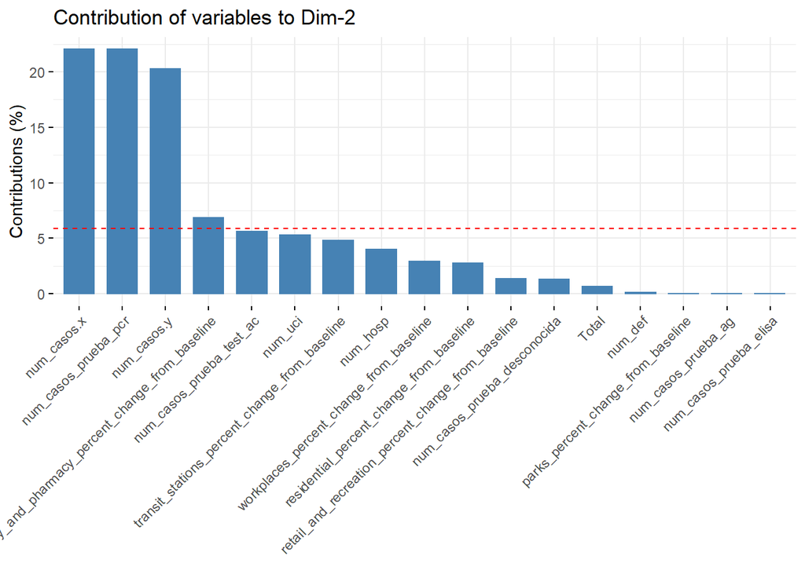

```r
fviz_contrib(pca, choice = "var", axes = 2)
```

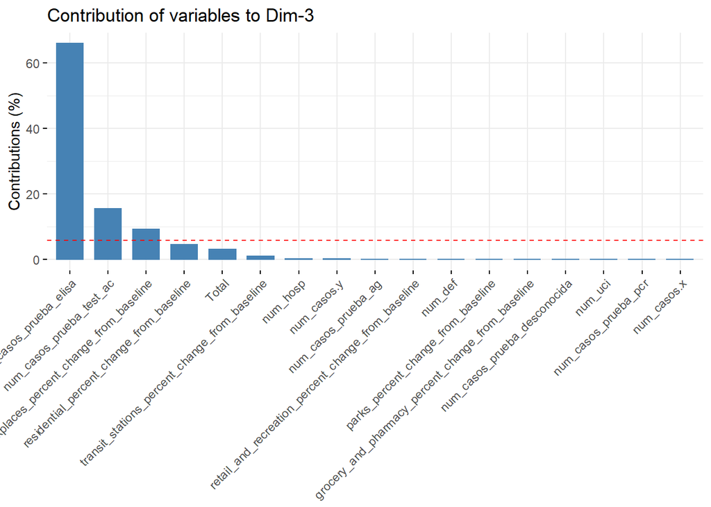

```r
fviz_contrib(pca, choice = "var", axes = 3)
```

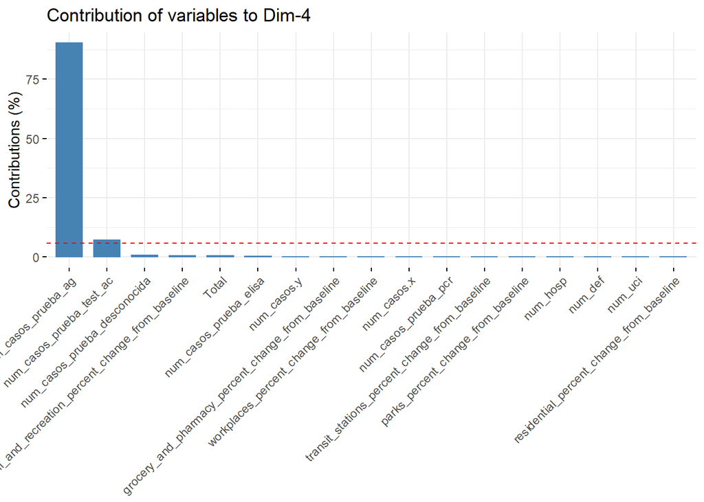

```r
fviz_contrib(pca, choice = "var", axes = 4)
```

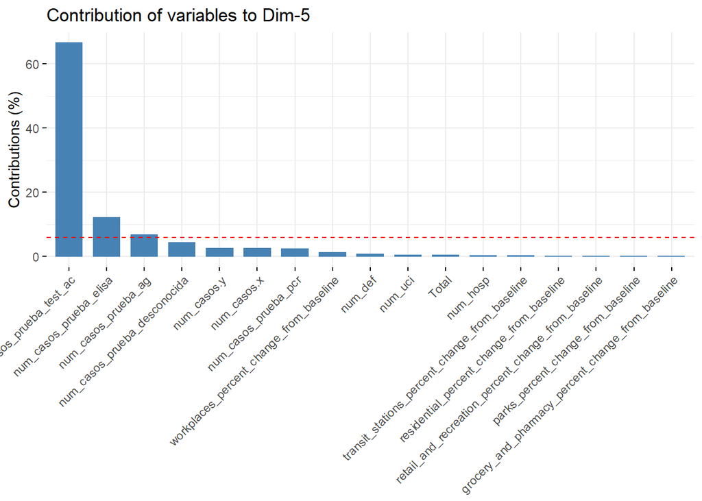

```r
fviz_contrib(pca, choice = "var", axes = 5)
```

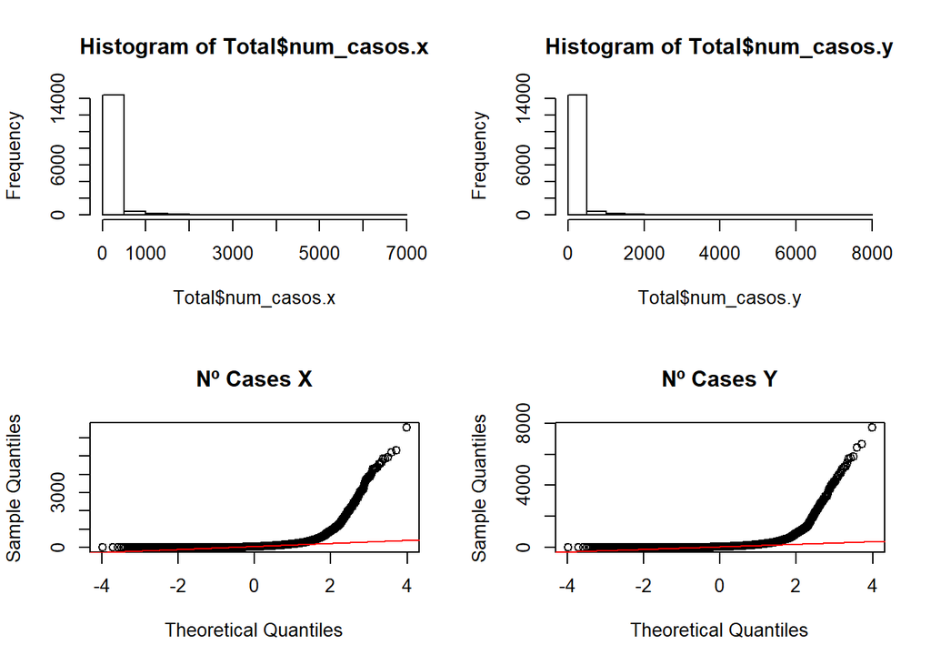

```r
par(mfrow=c(2,2))

hist(Total$num_casos.x)
hist(Total$num_casos.y)

qqnorm(Total$num_casos.x, main="Nº Cases X")
qqline(Total$num_casos.x,col=2)

qqnorm(Total$num_casos.y, main="Nº Cases Y")
qqline(Total$num_casos.y,col=2)
```

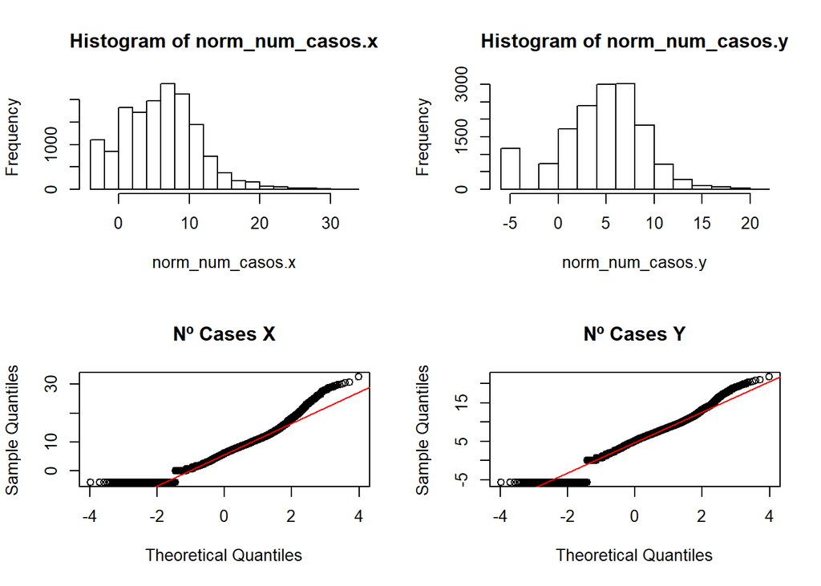

```r
#############################################
norm_num_casos.x <- BoxCox(Total$num_casos.x, lambda = BoxCoxLambda(Total$num_casos.x))
norm_num_casos.y <- BoxCox(Total$num_casos.y, lambda = BoxCoxLambda(Total$num_casos.y))

hist(norm_num_casos.x)
hist(norm_num_casos.y)

qqnorm(norm_num_casos.x, main="Nº Cases X")
qqline(norm_num_casos.x,col=2)

qqnorm(norm_num_casos.y, main="Nº Cases Y")
qqline(norm_num_casos.y,col=2)
```

```r
# Columns removal according PCA results and SME knowledge
Total_ts <- Total_ts[c(-4,-5,-6,-8)]
Total_ts_b <- Total_ts_b[c(-4,-5,-6,-8)]
table(Total_ts$sub_region_2)
```

```
##
##               Albacete       Alicante/Alacant                Almería
##                    290                    290                    290
##            Araba/Álava               Asturias                  Ávila
##                    290                    290                    290
##                Badajoz         Balears, Illes              Barcelona
##                    290                    290                    290
##                Bizkaia                 Burgos                Cáceres
##                    290                    290                    290
##                  Cádiz              Cantabria     Castellón/Castelló
##                    290                    290                    290
##                  Ceuta            Ciudad Real                Córdoba
##                    290                    290                    290
##              Coruña, A                 Cuenca               Gipuzkoa
##                    290                    290                    290
##                 Girona                Granada            Guadalajara
##                    290                    290                    290
##                 Huelva                 Huesca                   Jaén
##                    290                    290                    290
##                   León                 Lleida                   Lugo
##                    290                    290                    290
##                 Madrid                 Málaga                Melilla
##                    290                    290                    290
##                 Murcia                Navarra                Ourense
##                    290                    290                    290
##               Palencia            Palmas, Las             Pontevedra
##                    290                    290                    290
##              Rioja, La              Salamanca Santa Cruz de Tenerife
##                    290                    290                    290
##                Segovia                Sevilla                  Soria
##                    290                    290                    290
##              Tarragona                 Teruel                 Toledo
##                    290                    290                    290
##      Valencia/València             Valladolid                 Zamora
##                    290                    290                    290
##               Zaragoza
##                    290
```

```r
str(Total_ts)
```

```
## tsibble [15,080 x 15] (S3: tbl_ts/tbl_df/tbl/data.frame)
##  $ sub_region_2                                      : chr [1:15080] "Albacete" "Albacete" "Albacete" "Albacete" ...
##  $ num_casos.x                                       : int [1:15080] 137 128 114 149 131 129 125 112 107 78 ...
##  $ num_casos_prueba_pcr                              : int [1:15080] 132 123 107 133 121 120 112 103 91 64 ...
##  $ num_casos_prueba_desconocida                      : int [1:15080] 0 0 0 0 0 0 0 0 0 0 ...
##  $ num_hosp                                          : int [1:15080] 43 40 24 40 63 60 61 108 76 66 ...
##  $ num_uci                                           : int [1:15080] 3 4 7 5 4 2 8 2 7 9 ...
##  $ num_def                                           : int [1:15080] 7 2 7 7 6 10 13 16 14 16 ...
##  $ retail_and_recreation_percent_change_from_baseline: num [1:15080] -81 -84 -83 -93 -87 -92 -94 -85 -87 -87 ...
##  $ grocery_and_pharmacy_percent_change_from_baseline : num [1:15080] -32 -41 -32 -92 -34 -60 -80 -46 -55 -55 ...
##  $ parks_percent_change_from_baseline                : num [1:15080] -73 -74 -70 -80 -74 -85 -88 -77 -81 -76 ...
##  $ transit_stations_percent_change_from_baseline     : num [1:15080] -66 -72 -70 -86 -76 -80 -89 -76 -79 -78 ...
##  $ workplaces_percent_change_from_baseline           : num [1:15080] -51 -56 -58 -85 -68 -64 -66 -61 -64 -65 ...
##  $ residential_percent_change_from_baseline          : num [1:15080] 22 23 23 35 32 27 23 26 28 28 ...
##  $ Total                                             : num [1:15080] 9.9 9.71 9.51 9.13 8.75 ...
##  $ Dia_c                                             : Date[1:15080], format: "2020-03-16" "2020-03-17" ...
##  - attr(*, "key")= tibble [52 x 2] (S3: tbl_df/tbl/data.frame)
##   ..$ sub_region_2: chr [1:52] "Albacete" "Alicante/Alacant" "Almería" "Araba/Álava" ...
##   ..$ .rows       : list<int> [1:52]
##   .. ..$ : int [1:290] 1 2 3 4 5 6 7 8 9 10 ...
##   .. ..$ : int [1:290] 291 292 293 294 295 296 297 298 299 300 ...
##   .. ..$ : int [1:290] 581 582 583 584 585 586 587 588 589 590 ...
##   .. ..$ : int [1:290] 871 872 873 874 875 876 877 878 879 880 ...
##   .. ..$ : int [1:290] 1161 1162 1163 1164 1165 1166 1167 1168 1169 1170 ...
##   .. ..$ : int [1:290] 1451 1452 1453 1454 1455 1456 1457 1458 1459 1460 ...
##   .. ..$ : int [1:290] 1741 1742 1743 1744 1745 1746 1747 1748 1749 1750 ...
##   .. ..$ : int [1:290] 2031 2032 2033 2034 2035 2036 2037 2038 2039 2040 ...
##   .. ..$ : int [1:290] 2321 2322 2323 2324 2325 2326 2327 2328 2329 2330 ...
##   .. ..$ : int [1:290] 2611 2612 2613 2614 2615 2616 2617 2618 2619 2620 ...
##   .. ..$ : int [1:290] 2901 2902 2903 2904 2905 2906 2907 2908 2909 2910 ...
##   .. ..$ : int [1:290] 3191 3192 3193 3194 3195 3196 3197 3198 3199 3200 ...
##   .. ..$ : int [1:290] 3481 3482 3483 3484 3485 3486 3487 3488 3489 3490 ...
##   .. ..$ : int [1:290] 3771 3772 3773 3774 3775 3776 3777 3778 3779 3780 ...
##   .. ..$ : int [1:290] 4061 4062 4063 4064 4065 4066 4067 4068 4069 4070 ...
##   .. ..$ : int [1:290] 4351 4352 4353 4354 4355 4356 4357 4358 4359 4360 ...
##   .. ..$ : int [1:290] 4641 4642 4643 4644 4645 4646 4647 4648 4649 4650 ...
##   .. ..$ : int [1:290] 4931 4932 4933 4934 4935 4936 4937 4938 4939 4940 ...
##   .. ..$ : int [1:290] 5221 5222 5223 5224 5225 5226 5227 5228 5229 5230 ...
##   .. ..$ : int [1:290] 5511 5512 5513 5514 5515 5516 5517 5518 5519 5520 ...
##   .. ..$ : int [1:290] 5801 5802 5803 5804 5805 5806 5807 5808 5809 5810 ...
```

[output cut: 23 more lines]

```
##   .. ..$ : int [1:290] 12761 12762 12763 12764 12765 12766 12767 12768 12769 12770 ...
##   .. ..$ : int [1:290] 13051 13052 13053 13054 13055 13056 13057 13058 13059 13060 ...
##   .. ..$ : int [1:290] 13341 13342 13343 13344 13345 13346 13347 13348 13349 13350 ...
##   .. ..$ : int [1:290] 13631 13632 13633 13634 13635 13636 13637 13638 13639 13640 ...
##   .. ..$ : int [1:290] 13921 13922 13923 13924 13925 13926 13927 13928 13929 13930 ...
##   .. ..$ : int [1:290] 14211 14212 14213 14214 14215 14216 14217 14218 14219 14220 ...
##   .. ..$ : int [1:290] 14501 14502 14503 14504 14505 14506 14507 14508 14509 14510 ...
##   .. ..$ : int [1:290] 14791 14792 14793 14794 14795 14796 14797 14798 14799 14800 ...
##   .. ..@ ptype: int(0)
##   ..- attr(*, ".drop")= logi TRUE
##  - attr(*, "index")= chr "Dia_c"
##   ..- attr(*, "ordered")= logi TRUE
##  - attr(*, "index2")= chr "Dia_c"
##  - attr(*, "interval")= interval [1:1] 1D
##   ..@ .regular: logi TRUE
```

```r
summary(Total_ts)
```

```
##  sub_region_2        num_casos.x   num_casos_prueba_pcr
##  Length:15080       Min.   :   0   Min.   :   0.0
##  Class :character   1st Qu.:   5   1st Qu.:   5.0
##  Mode  :character   Median :  39   Median :  35.0
##                     Mean   : 126   Mean   : 110.2
##                     3rd Qu.: 120   3rd Qu.: 105.0
##                     Max.   :6565   Max.   :6546.0
##  num_casos_prueba_desconocida    num_hosp          num_uci
##  Min.   : 0.0000              Min.   :   0.00   Min.   :  0.000
##  1st Qu.: 0.0000              1st Qu.:   1.00   1st Qu.:  0.000
##  Median : 0.0000              Median :   4.00   Median :  0.000
##  Mean   : 0.1317              Mean   :  14.86   Mean   :  1.281
##  3rd Qu.: 0.0000              3rd Qu.:  12.00   3rd Qu.:  1.000
##  Max.   :65.0000              Max.   :1930.00   Max.   :135.000
##     num_def        retail_and_recreation_percent_change_from_baseline
##  Min.   :  0.000   Min.   :-97.00
##  1st Qu.:  0.000   1st Qu.:-57.00
##  Median :  1.000   Median :-30.00
##  Mean   :  3.437   Mean   :-37.29
##  3rd Qu.:  3.000   3rd Qu.:-17.00
##  Max.   :334.000   Max.   : 71.00
##  grocery_and_pharmacy_percent_change_from_baseline
##  Min.   :-96.00
##  1st Qu.:-24.00
##  Median : -6.00
##  Mean   :-11.75
##  3rd Qu.:  4.00
##  Max.   :194.00
##  parks_percent_change_from_baseline
##  Min.   :-94.000
##  1st Qu.:-30.000
##  Median : -2.000
##  Mean   :  5.809
##  3rd Qu.: 30.000
##  Max.   :543.000
##  transit_stations_percent_change_from_baseline
##  Min.   :-100.00
##  1st Qu.: -53.00
##  Median : -31.00
##  Mean   : -35.19
##  3rd Qu.: -17.00
##  Max.   :  74.00
##  workplaces_percent_change_from_baseline
##  Min.   :-92.00
##  1st Qu.:-43.00
##  Median :-26.00
##  Mean   :-29.08
##  3rd Qu.:-13.00
##  Max.   : 55.00
##  residential_percent_change_from_baseline     Total           Dia_c
##  Min.   :-10.00                           Min.   : 1.95   Min.   :2020-03-16
##  1st Qu.:  4.00                           1st Qu.:11.36   1st Qu.:2020-05-27
##  Median :  7.00                           Median :14.39   Median :2020-08-07
##  Mean   : 10.14                           Mean   :14.20   Mean   :2020-08-07
##  3rd Qu.: 14.00                           3rd Qu.:17.11   3rd Qu.:2020-10-19
##  Max.   : 48.00                           Max.   :29.00   Max.   :2020-12-30
```

# 3 Seasonal and trend decomposition

### 3.0.1 ACF

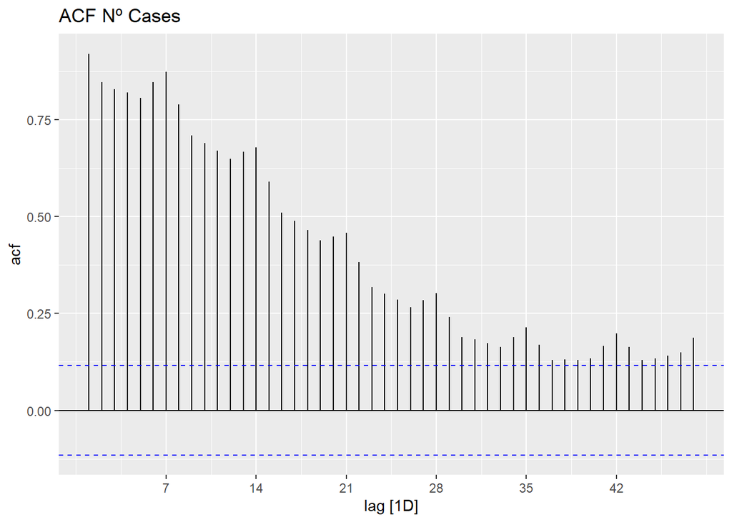

```r
# Filter time-series for Bar, Mad, Mal, Cor and, Cad
Total_ts_b %>%
  filter(sub_region_2 == "Barcelona") %>%
  ACF(num_casos.x, lag_max = 48) %>%
  autoplot() +
  labs(title="ACF Nº Cases")
```

## 3.1 STL (Seasonal and Trend decomposition using Loess)

As stated by (Hyndman and Athanasopoulos 2021)… "STL has several advantages over classical decomposition, and the SEATS and X-11 methods:

- Unlike SEATS and X-11, STL will handle any type of seasonality, not only monthly and quarterly data.
- The seasonal component is allowed to change over time, and the rate of change can be controlled by the user.
- The smoothness of the trend-cycle can also be controlled by the user.
- It can be robust to outliers (i.e., the user can specify a robust decomposition), so that occasional unusual observations will not affect the estimates of the trend-cycle and seasonal components. They will, however, affect the remainder component"…

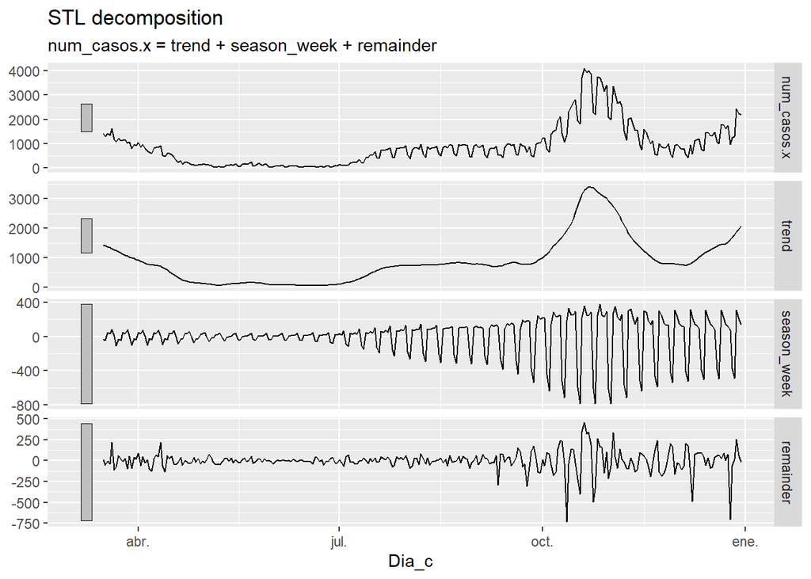

```r
dcmp <- Total_ts %>%
  filter(sub_region_2 == "Barcelona") %>%
  model(STL(num_casos.x))

components(dcmp) %>% autoplot()
```

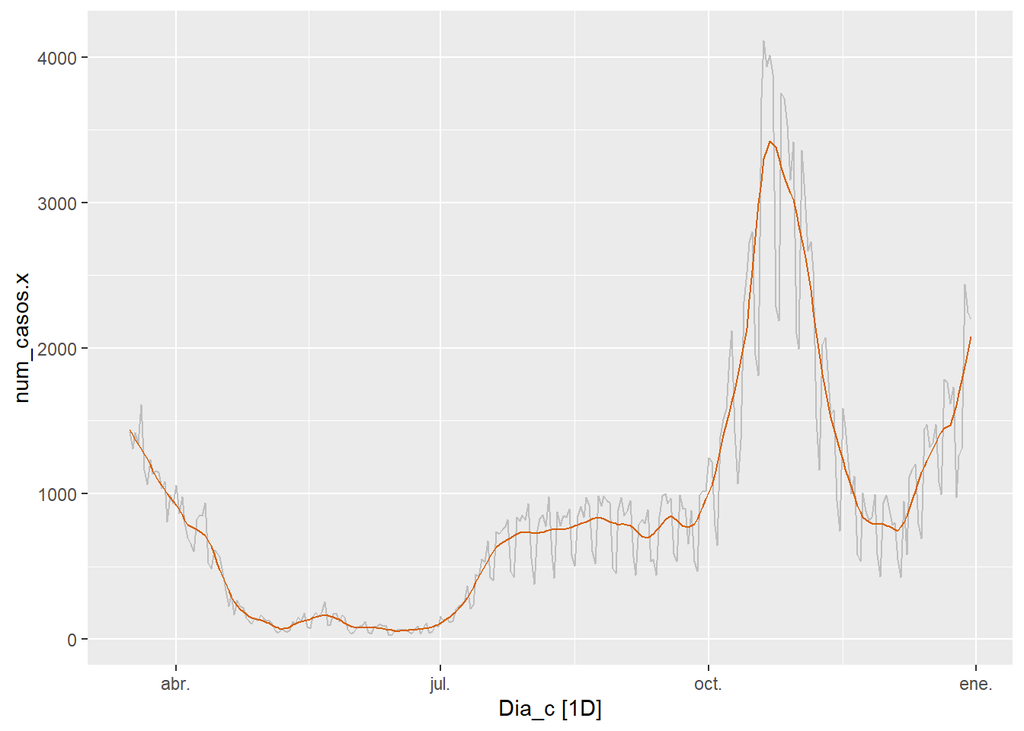

```r
components(dcmp) %>%
  as_tsibble() %>%
  autoplot(num_casos.x, color="gray") +
  geom_line(aes(y=trend), color = "#D55E00")
```

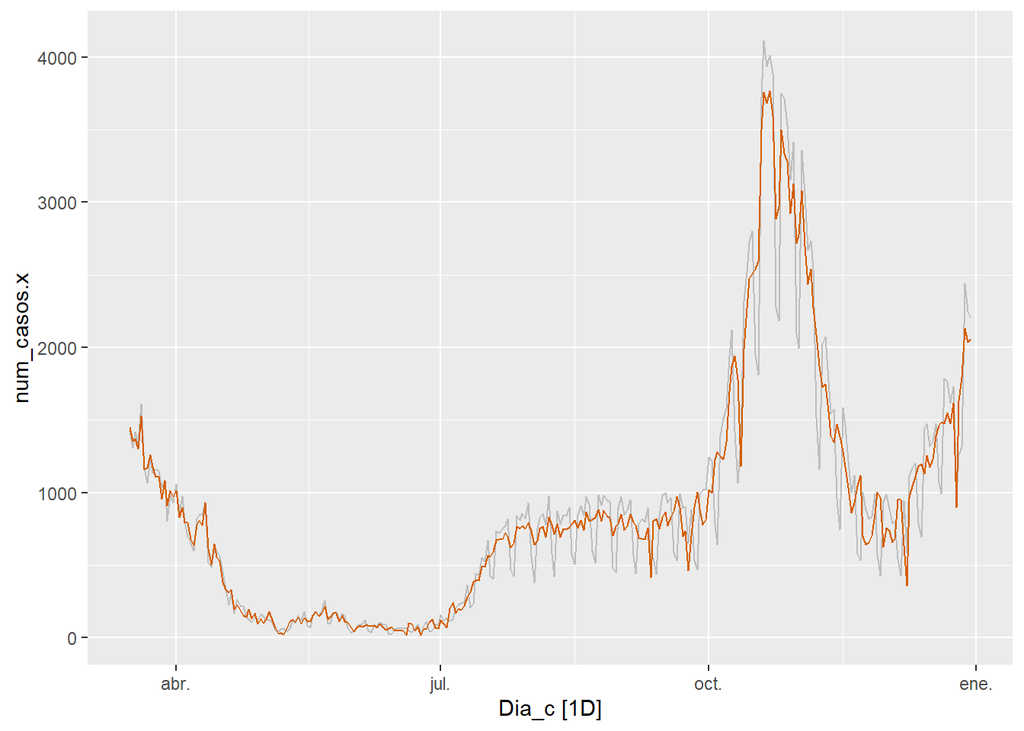

```r
components(dcmp) %>%
  as_tsibble() %>%
  autoplot(num_casos.x, color="gray") +
  geom_line(aes(y=season_adjust), color = "#D55E00")
```

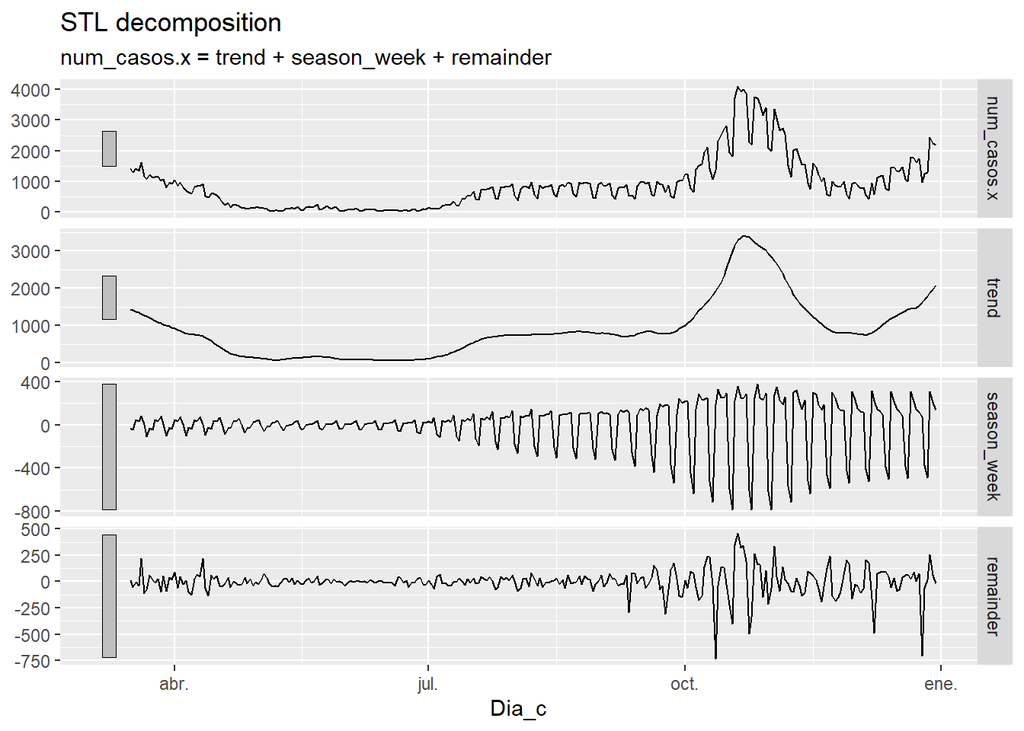

```r
#############################
Total_ts %>%
  filter(sub_region_2 == "Barcelona") %>%
  model(STL(num_casos.x)) %>%
  components() %>%
  autoplot()
```

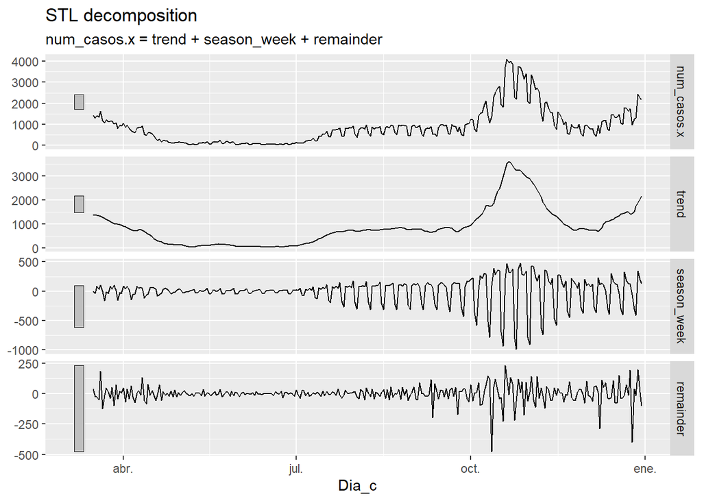

```r
Total_ts %>%
  filter(sub_region_2 == "Barcelona") %>%
  model(STL(num_casos.x ~ season(window = 7) +
              trend(window = 7))) %>%
  components() %>%
  autoplot()
```

## 3.2 Till here 06-Apr-2021

# Bibliography

Baayen, R Harald. 2008. *Analyzing Linguistic Data: A Practical Introduction to Statistics Using R*. Cambridge University Press.

Hothorn, Torsten, and Brian S Everitt. 2014. *A Handbook of Statistical Analyses Using R*. CRC press.

Hyndman, Rob J., and George Athanasopoulos. 2021. “Forecasting: Principles and Practice, 3rd.” OTexts: Melbourne, Australia. OTexts.com.

Liviano Solas, Daniel, and Maria Pujol Jover. n.d. *Analisis de Datos Y Estadastica Descriptiva Con R Y R-Commander*. UOC.

Teetor, Paul. 2011. *R Cookbook: Proven Recipes for Data Analysis, Statistics, and Graphics*. O’Reilly Media, Inc.

Vegas Lozano, Esteban. n.d. *Preprocesamiento de Los Datos*. UOC.